# CDB Incidence Rate Investigation

# Data

For convenience, only one year of exposure records was used: 2010. So the dataset is the concatenation of the 2010 exposure records with the 2005-2013 claims records. The year 2010 was not chosen for any particular reason.

Data was gathered from the source files using Python. All sheets in “EPallExp2016CDBStudy_2010.xlsb” were concatenated then saved as “exposure.csv”; the data in “20171105 CDB CLAIMS- sponsors db.xlsb” was saved as “claims.csv”.

# Preamble

Packages, settings, and data import are in the code below.

```r
### PREAMBLE ---------------------------------------------------
### General
library(magrittr)       # extend R syntax with %>% notation
library(tidyverse)      # data manipulation
library(stringr)        # string manipulation
library(skimr)          # data summaries
library(knitr)          # rendering R objects into Markdown

### Plotting
library(ggcorrplot)     # correlation plots for ggplot2
library(gridExtra)      # arranging multiple plots for ggplot2
### Statistics
library(caret)          # partition data
library(sandwich)       # gets heteroskedastic standard errors from regression
library(logistf)        # penalized logistic regressions
library(glmnet)         # ridge regression
library(pracma)         # for matrix algebra
### Settings
options(scipen = 999)   # removes scientific notation for small numbers

### Import data
# Data was compiled from source in Python.
exposure <-
  read.csv("~/CDB/exposure.csv",
           na.strings = c(""),
           stringsAsFactors = T)
claims <-
  read.csv("~/CDB/claims.csv",
           na.strings = c(""),
           stringsAsFactors = T)

# Create Y variable and concatenate
exposure$claim <- 0
claims$claim <- 1
data.initial <- rbind(exposure, claims)
```

# Data Summary

### Set-up

```r
### Create summary of dataset
mySummary <- function(data, y) {
  require(magrittr)
  n <- dim(data)[1]
  v <- dim(data)[2]
  c <- sum(y)
  e <- n - c
  labels <- c("Number of Observations",
              "Number of Variables",
              "Claims",
              "Exposure")
  output <- data.frame(labels, c(n, v, c, e))
  colnames(output) <- c("Summary", "Values")
  return(output)
}
data.initial.summary <- mySummary(data.initial, data.initial$claim)

### Create summary of variables using package skimr
# Define summary statistics (skimmers)
base.skimmers <- sfl(missing_values = n_missing)

skimList <- function(x) {
  levels <- levels(x)
  paste0(levels, collapse = ", ")
}

factor.skimmers <- sfl(
  n_unique = "n_unique",
  categories = skimList,
  ordered = NULL,
  top_counts = NULL
)

numeric.skimmers <- sfl(hist = NULL)

# Compile the skimming function
mySkim <- skim_with(numeric = numeric.skimmers,
                    base = base.skimmers,
                    factor = factor.skimmers)

# Need industry to be numeric for later processing
# For summary purposes replace it with a factor
data.initial.industryfactor <-
  mutate(data.initial, NAISC = as.factor(NAISC))
data.initial.skim <- mySkim(data.initial.industryfactor)
```

### Summary

```r
# Overall summary
kable(data.initial.summary,
      digits = 0,
      format.args = list(big.mark = ","))
```

| Summary | Values |
| --- | --- |
| Number of Observations | 1,218,936 |
| Number of Variables | 6 |
| Claims | 94,396 |
| Exposure | 1,124,540 |

The incidence rate in this dataset is 0.0774.

### Factor Variables

```r
# Factor variables summary
data.initial.skim.factor <- yank(data.initial.skim, "factor")
colnames(data.initial.skim.factor) <- data.initial.skim.factor %>%
  colnames() %>%
  str_replace("_", " ") %>%
  str_to_title()
kable(data.initial.skim.factor)
```

| Skim Variable | Missing Values | N Unique | Categories |
| --- | --- | --- | --- |
| NAISC | 46 | 26 | 11, 21, 22, 23, 31, 33, 41, 44, 48, 51, 52, 53, 54, 55, 56, 61, 62, 63, 71, 72, 81, 91, 96, 97, 98, 99 |
| Province | 46 | 15 | AB, BC, MB, NB, NL, NS, NT, NU, ON, PE, QC, RC, SK, YK, XX |
| Gender | 46 | 2 | F, M |

### Numeric Variables

```r
# Numeric variables summary
data.initial.skim.numeric <- yank(data.initial.skim, "numeric")
colnames(data.initial.skim.numeric) <- data.initial.skim.numeric %>%
  colnames() %>%
  str_replace("_", " ") %>%
  str_to_title()
colnames(data.initial.skim.numeric)[5:9] <-
  c("Min", "1st Qu.", "Median", "3rd Qu.", "Max")
kable(data.initial.skim.numeric, digits = 2)
```

| Skim Variable | Missing Values | Mean | Sd | Min | 1st Qu. | Median | 3rd Qu. | Max |
| --- | --- | --- | --- | --- | --- | --- | --- | --- |
| Benefit | 46 | 2509.48 | 1203.82 | 0 | 1740 | 2229 | 3000 | 20000 |
| Age | 46 | 42.43 | 11.23 | 0 | 33 | 43 | 51 | 111 |
| claim | 0 | 0.08 | 0.27 | 0 | 0 | 0 | 0 | 1 |

# Data Cleaning

### Missing Values

There 46 rows with missing values (not including industry codes 96 to 99), which are all from the exposure dataset (Y=0). Drop these values, as the effect is negligible. First few rows shown below.

```r
# Retrieve rows with missing values
data.na <- subset(data.initial, rowSums(is.na(data.initial)) > 0)
kable(data.na[-1] %>% head %>% as_tibble(),
      col.names = c("Province","Gender","Benefit","Age","Claim"),
      align = "l")
```

| Province | Gender | Benefit | Age | Claim |
| --- | --- | --- | --- | --- |
| NA | NA | NA | NA | 0 |
| NA | NA | NA | NA | 0 |
| NA | NA | NA | NA | 0 |
| NA | NA | NA | NA | 0 |
| NA | NA | NA | NA | 0 |
| NA | NA | NA | NA | 0 |

```r
# Remove these 46 rows. Small amount and all have Y=0
data <- subset(data.initial, rowSums(is.na(data.initial)) == 0)
```

### Age

Looking at the tail ends of the age distribution, there are unexpected data at the minimum and maximum: age = 0 and age = 111. To simplify the problem, these rows will be removed along rows for very low and very high ages: under 16 and over 64. 18 exposure and 2 claim rows were removed for ages under 16, and 2186 exposure and 287 claim rows were removed for ages over 64.

**Lower tail**

```r
# Before starting, rename variables for convenience
colnames(data) <- str_to_lower(colnames(data)) %>%
  str_replace("province", "prov") %>%
  str_replace("benefit", "ben")

age.freq <- with(data, table(age, claim))

# Tail ends of age distribution
age.freq.low <- age.freq[as.numeric(rownames(age.freq)) < 16, ] %>%
  rbind(Total = age.freq[as.numeric(rownames(age.freq)) < 16, ] %>% colSums())
kable(tibble(Age = labels(age.freq.low)[[1]],
                Exposure = age.freq.low[,1],
                Claims = age.freq.low[,2]))
```

| Age | Exposure | Claims |
| --- | --- | --- |
| 0 | 7 | 0 |
| 2 | 2 | 0 |
| 9 | 0 | 1 |
| 11 | 3 | 0 |
| 12 | 3 | 0 |
| 13 | 1 | 0 |
| 15 | 2 | 1 |
| Total | 18 | 2 |

**Upper tail**

```r
age.freq.high <- age.freq[as.numeric(rownames(age.freq)) > 64, ] %>%
  rbind(Total = age.freq[as.numeric(rownames(age.freq)) > 64, ] %>% colSums())
kable(tibble(Age = labels(age.freq.high)[[1]],
                Exposure = age.freq.high[,1],
                Claims = age.freq.high[,2]) %>% tail)
```

| Age | Exposure | Claims |
| --- | --- | --- |
| 86 | 2 | 0 |
| 87 | 1 | 0 |
| 89 | 1 | 0 |
| 90 | 1 | 0 |
| 111 | 104 | 0 |
| Total | 2186 | 287 |

```r
# Set min and max for age, removing extreme data
# Removed 2186 Y=0 and 287 Y=1 for age > 64
# Removed 18 Y=0 and 2 Y=1 for age < 16
age.min <- 16
age.max <- 64
data <- subset(data, (age > age.min & age < age.max))
```

### Region

Nonstandard province names “RC” and “XX” were removed. There were 30 exposure rows and 4 claim rows.

```r
prov.freq <- with(data, table(prov, claim))
prov.freq.bad <- prov.freq[rownames(prov.freq) %in% c("RC", "XX"), ]
kable(tibble(Province = labels(prov.freq)[[1]],
                Exposure = prov.freq[,1],
                Claims = prov.freq[,2]))
```

| Province | Exposure | Claims |
| --- | --- | --- |
| AB | 130720 | 5769 |
| BC | 99653 | 5314 |
| MB | 44059 | 2320 |
| NB | 22510 | 1460 |
| NL | 10485 | 648 |
| NS | 26605 | 1565 |
| NT | 1689 | 63 |
| NU | 270 | 2 |
| ON | 359528 | 19705 |
| PE | 3704 | 248 |
| QC | 379604 | 53624 |
| RC | 30 | 0 |
| SK | 35194 | 1880 |
| YK | 834 | 44 |
| XX | 0 | 4 |

```r
# Remove 30 Y=0 and 4 Y=1 rows with Provinces RC and XX, map to ROC/QC
data <- subset(data, (prov != "RC" & prov != "XX")) %>%
  mutate(region = factor(ifelse(prov == "QC", "QC", "ROC"),
                         levels = c("ROC", "QC")))
```

### Industry

Due to lack of observations in some industries as well as the hypothesis that some industries will behave similarly in terms of incidence rates, standard NAISC industry codes have been mapped as follows:

- Blue Collar: codes 11, 21, 22, 23, 31, 33, 56
- Trade & Services: codes 41, 44, 48, 71, 72, 81
- White Collar: codes 51, 52, 53, 54, 55
- Public Services: codes 61, 62, 63, 91

```r
naisc.freq <- with(data, table(naisc, claim))

# Condense categories based on similarities for better prediction
industry.levels <- c(
  "BlueCollar",
  "TradeAndServices",
  "WhiteCollar",
  "PublicServices",
  "Invalid",
  "Missing",
  "Unmappable",
  "Unknown"
)

industryMapping <- function(x, levels) {
  require(magrittr)
  bc <- c(11, 21, 22, 23, 31, 33, 56)
  ts <- c(41, 44, 48, 71, 72, 81)
  wc <- c(51, 52, 53, 54, 55)
  ps <- c(61, 62, 63, 91)
  y <- case_when(
    x %in% bc ~ levels[1],
    x %in% ts ~ levels[2],
    x %in% wc ~ levels[3],
    x %in% ps ~ levels[4],
    x == 96 ~ levels[5],
    x == 97 ~ levels[6],
    x == 98 ~ levels[7],
    x == 99 ~ levels[8]
  ) %>%
    factor(levels = levels)
  return(y)
}

data$industry <- industryMapping(data$naisc, industry.levels)

# Double-check data
data.na2 <- subset(data, rowSums(is.na(data)) > 0)
```

The nonstandard industry codes remain as-is, due to observed correlation between these codes and their incidence rates. See chart and graphs in the Data Exploration section for Industry below.

# Data Exploration

Set-up: the following two functions were used to making incidence plots. plotIncidence is for one-variable comparisons (e.g. incidence rate by age) and plotIncidence2 is for two-variable comparisons (e.g. incidence rate by age and gender).

```r
plotIncidence <- function(data, x, y, ...) {
  require(magrittr)
  require(ggplot2)
  x.name <- deparse(substitute(x))
  y.name <- deparse(substitute(y))
  x <- data[[x.name]]
  y <- data[[y.name]]
  index <- sort(unique(x))
  plot <- prop.table(table(x, y), 1)[, 2] %>%
    as.data.frame() %>%
    cbind(index) %>%
    setNames(c("incidence", x.name)) %>%
    ggplot(aes(x = index, y = incidence)) +
    geom_point() +
    labs(
      ...,
      subtitle = paste(
        "Exposure =",
        as.character(dim(data)[1] - sum(y)),
        ", Claims = ",
        as.character(sum(y))
      ),
      x = str_to_title(x.name),
      y = "Incidence"
    ) +
    theme_light() +
    scale_x_continuous(expand = c(0, 0), limits = c(min(x) - 1, max(x) + 1))
  return(plot)
}
plotIncidence2 <- function(data, x1, x2, y, ..., palette) {
  # for three-way tabulation, where the third var (x2) is binary
  require(magrittr)
  require(ggplot2)
  x1.name <- deparse(substitute(x1))
  x2.name <- deparse(substitute(x2))
  y.name <- deparse(substitute(y))

  x1 <- data[[x1.name]]
  x2 <- data[[x2.name]]
  y <- data[[y.name]]

  probA <- prop.table(table(x1, x2, y), 1)[, 1, 2]
  probB <- prop.table(table(x1, x2, y), 1)[, 2, 2]


  x1.data <- c(rep(sort(unique(x1)), 2))
  y.data <- c(probA, probB)

  x2.levels <- levels(x2)
  x2.data <- c(rep(x2.levels[1], length(probA)),
               rep(x2.levels[2], length(probB)))

  prob <- data.frame(
    x1.name = c(rep(sort(unique(
      x1
    )), 2)),
    incidence = c(probA, probB),
    x2.name = c(rep(x2.levels[1], length(probA)),
                rep(x2.levels[2], length(probB)))
  )

  freq <- table(x2, y)
  subtitle <- str_c(
    x2.levels[1],
    ": Exposure = ",
    format(freq[1, 1], big.mark = ",", scientific = FALSE),
    ", Claims = ",
    format(freq[1, 2], big.mark = ",", scientific = FALSE),
    "\n",
    x2.levels[2],
    ": Exposure = ",
    format(freq[2, 1], big.mark = ",", scientific = FALSE),
    ", Claims = ",
    format(freq[2, 2], big.mark = ",", scientific = FALSE)
  )

  plot <-
    ggplot(prob, aes(x = x1.name, y = incidence, color = x2.name)) +
    geom_point() +
    labs(
      ...,
      x = str_to_title(x1.name),
      y = "Incidence",
      subtitle = subtitle,
      color = str_to_title(x2.name)
    ) +
    theme_light() +
    scale_color_manual(values = palette) +
    scale_x_continuous(expand = c(0, 0), limits = c(15, 65)) +
    scale_y_continuous(expand = c(0, 0), limits = c(0, max(y.data) * 1.05))
  return(plot)
}
```

### Age

As expected, incidence increases smoothly with age. For this reason, plots of all non-numeric variables will use age on the x-axis.

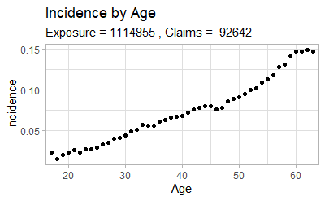

```r
plotIncidence(data, age, claim, title = "Incidence by Age")
```

### Nonstandard industry codes

This may distort the model estimates and its predictive ability beyond the CDB.

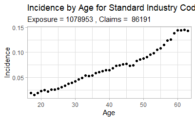

```r
# Before deciding how to handle them, need to look for patterns
plot.i.s <- plotIncidence(subset(data, industry %in% industry.levels[1:4]), age, claim,
                        title = "Incidence by Age for Standard Industry Codes")
plot.i.ns <- plotIncidence(subset(data, industry %in% industry.levels[5:8]), age, claim,
                        title = "Incidence by Age for Nonstandard Industry Codes")
plot.i.i <- plotIncidence(subset(data, data$industry == "Invalid"), age, claim,
                          title = "Incidence by Age for Industry = 96\n(invalid code)")
plot.i.mi <- plotIncidence(subset(data, data$industry == "Missing"), age, claim,
                           title = "Incidence by Age for Industry = 97\n(missing code)")
plot.i.um <- plotIncidence(subset(data, data$industry == "Unmappable"), age, claim,
                           title = "Incidence by Age for Industry = 98\n(unmappable code)")
plot.i.uk <- plotIncidence(subset(data, industry == "Unknown"), age, claim,
                           title = "Incidence by Age for Industry = 99\n(unknown code)")
plot.i.bc <- plotIncidence(subset(data, industry == "BlueCollar"), age, claim,
                           title = "Incidence by Age for\nIndustry = Blue Collar")
plot.i.ts <- plotIncidence(subset(data, industry == "TradeAndServices"), age, claim,
                           title = "Incidence by Age for\nIndustry = Trade And Services")
plot.i.wc <- plotIncidence(subset(data, industry == "WhiteCollar"), age, claim,
                           title = "Incidence by Age for\nIndustry = White Collar")
plot.i.ps <- plotIncidence(subset(data, industry == "PublicServices"), age, claim,
                           title = "Incidence by Age for\nIndustry = PublicServices")

plot.i.s
```

[figure not shown]

```r
grid.arrange(plot.i.bc, plot.i.ts, plot.i.wc, plot.i.ps, nrow = 2)
```

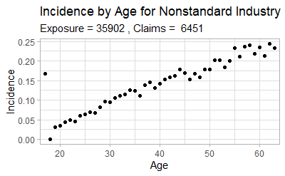

```r
# Plots show there is an higher correlation between these codes and incidence
plot.i.ns
```

[figure not shown]

```r
grid.arrange(plot.i.i, plot.i.mi, plot.i.um, plot.i.uk, nrow = 2)
```

### Gender

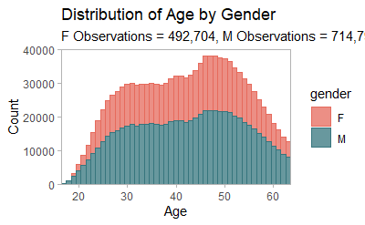

```r
palette.g <- c("#e66a5c", "#36757d")
hist.g <-
  ggplot(data, aes(x = age, color = gender, fill = gender)) +
  geom_histogram(binwidth = 1,
                 alpha = 0.75,
                 position = "stack") +
  labs(
    title = "Distribution of Age by Gender",
    x = "Age",
    y = "Count",
    subtitle = str_c(
      levels(data$gender)[1],
      " Observations = ",
      format(
        table(data$gender)[1],
        big.mark = ",",
        scientific = FALSE
      ),
      ", ",
      levels(data$gender)[2],
      " Observations = ",
      format(
        table(data$gender)[2],
        big.mark = ",",
        scientific = FALSE
      )
    )
  ) +
  theme_light() +
  theme(panel.grid.major = element_blank(),
        panel.grid.minor = element_blank()) +
  scale_color_manual(values = palette.g) +
  scale_fill_manual(values = palette.g) +
  scale_x_continuous(expand = c(0, 0)) +
  scale_y_continuous(expand = c(0, 0), limits = c(0, 40000))
hist.g
```

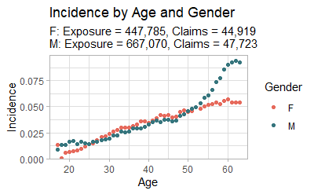

```r
plot.g <- plotIncidence2(data, age, gender, claim,
                         palette = palette.g,
                         title = "Incidence by Age and Gender")
plot.g
```

### Region

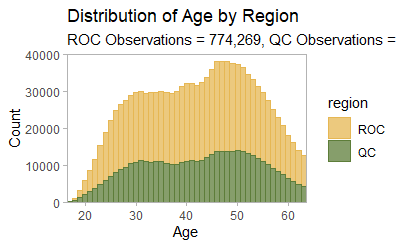

```r
palette.r <- c("#E6B753", "#5D7D39")
hist.r <-
  ggplot(data, aes(x = age, color = region, fill = region)) +
  geom_histogram(binwidth = 1,
                 alpha = 0.75,
                 position = "stack") +
  labs(
    title = "Distribution of Age by Region",
    x = "Age",
    y = "Count",
    subtitle = str_c(
      levels(data$region)[1],
      " Observations = ",
      format(
        table(data$region)[1],
        big.mark = ",",
        scientific = FALSE
      ),
      ", ",
      levels(data$region)[2],
      " Observations = ",
      format(
        table(data$region)[2],
        big.mark = ",",
        scientific = FALSE
      )
    )
  ) +
  theme_light() +
  theme(panel.grid.major = element_blank(),
        panel.grid.minor = element_blank()) +
  scale_color_manual(values = palette.r) +
  scale_fill_manual(values = palette.r) +
  scale_x_continuous(expand = c(0, 0)) +
  scale_y_continuous(expand = c(0, 0), limits = c(0, 40000))
hist.r
```

The distributions of ROC and QC observations appear similar in shape, while ROC overall has more observations.

Region plots are below.

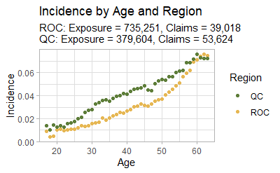

```r
plot.r <-
  plotIncidence2(data,
                 age,
                 region,
                 claim,
                 palette = rev(palette.r),
                 title = "Incidence by Age and Region")
plot.r
```

#### Region and Gender

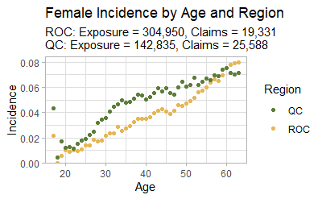

```r
plot.f.r <- plotIncidence2(subset(data, data$gender == "F"),
                           age,
                           region,
                           claim,
                           palette = rev(palette.r),
                           title = "Female Incidence by Age and Region")
plot.m.r <- plotIncidence2(subset(data, data$gender == "M"),
                           age,
                           region,
                           claim,
                           palette = rev(palette.r),
                           title = "Male Incidence by Age and Region")
plot.f.r
```

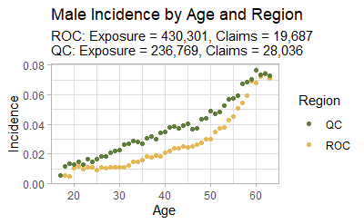

```r
plot.m.r
```

### Benefit Amounts

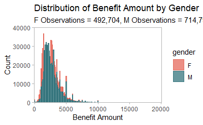

```r
# Round benefit amounts to nearest 10 for plotting
hist.b <-
  ggplot(data, aes(x = ben, color = gender, fill = gender)) +
  geom_histogram(binwidth = 100,
                 alpha = 0.75,
                 position = "stack") +
  labs(
    title = "Distribution of Benefit Amount by Gender",
    x = "Benefit Amount",
    y = "Count",
    subtitle = str_c(
      levels(data$gender)[1],
      " Observations = ",
      format(
        table(data$gender)[1],
        big.mark = ",",
        scientific = FALSE
      ),
      ", ",
      levels(data$gender)[2],
      " Observations = ",
      format(
        table(data$gender)[2],
        big.mark = ",",
        scientific = FALSE
      )
    )
  ) +
  theme_light() +
  theme(panel.grid.major = element_blank(),
        panel.grid.minor = element_blank()) +
  scale_color_manual(values = palette.g) +
  scale_fill_manual(values = palette.g) +
  scale_x_continuous(expand = c(0, 0)) +
  scale_y_continuous(expand = c(0, 0), limits = c(0, 40000))
hist.b
```

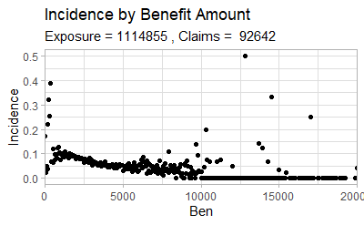

```r
plot.b <- plotIncidence(mutate(data, ben = round(ben*2, -2)/2),
                        ben, claim, title = "Incidence by Benefit Amount")
plot.b
```

Looking more closely, incidence rates by benefit amount seem to spike downwards when the benefit amount is a “nice” number. This is illustrated in the tables below; note they have been rounded to the nearest 50 for compactness.

Smaller benefit amounts tended to spikes downwards at amounts divisible by 100.

```r
freq.b <- table(round(data$ben,-2)/2, data$claim)
freq.b.output <-
  tibble(Benefit = labels(freq.b)[[1]],
                Exposure = freq.b[,1],
                Claims = freq.b[,2]) %>%
  mutate(Incidence = Claims/(Claims+Exposure))
kable(freq.b.output[27:37,], digits = c(0,0,0,4))
```

| Benefit | Exposure | Claims | Incidence |
| --- | --- | --- | --- |
| 1300 | 31365 | 2626 | 0.0773 |
| 1350 | 28830 | 2283 | 0.0734 |
| 1400 | 30659 | 2263 | 0.0687 |
| 1450 | 25206 | 1912 | 0.0705 |
| 1500 | 38444 | 2383 | 0.0584 |
| 1550 | 20245 | 1358 | 0.0629 |
| 1600 | 19174 | 1216 | 0.0596 |
| 1650 | 17439 | 1109 | 0.0598 |
| 1700 | 14562 | 919 | 0.0594 |
| 1750 | 21524 | 1277 | 0.0560 |
| 1800 | 12841 | 729 | 0.0537 |

For larger amounts, these spikes tended to occur at amounts divisible by 500.

```r
kable(freq.b.output[60:85,], digits = c(0,0,0,4))
```

| Benefit | Exposure | Claims | Incidence |
| --- | --- | --- | --- |
| 2950 | 1065 | 49 | 0.0440 |
| 3000 | 4650 | 144 | 0.0300 |
| 3050 | 884 | 60 | 0.0636 |
| 3100 | 1019 | 56 | 0.0521 |
| 3150 | 716 | 54 | 0.0701 |
| 3200 | 796 | 42 | 0.0501 |
| 3250 | 824 | 39 | 0.0452 |
| 3300 | 555 | 28 | 0.0480 |
| 3350 | 772 | 41 | 0.0504 |
| 3400 | 659 | 25 | 0.0365 |
| 3450 | 507 | 27 | 0.0506 |
| 3500 | 1192 | 42 | 0.0340 |
| 3550 | 405 | 17 | 0.0403 |
| 3600 | 482 | 13 | 0.0263 |
| 3650 | 372 | 19 | 0.0486 |
| 3700 | 306 | 10 | 0.0316 |
| 3750 | 1176 | 49 | 0.0400 |
| 3800 | 291 | 3 | 0.0102 |
| 3850 | 211 | 12 | 0.0538 |
| 3900 | 313 | 13 | 0.0399 |
| 3950 | 213 | 7 | 0.0318 |
| 4000 | 882 | 34 | 0.0371 |
| 4050 | 182 | 10 | 0.0521 |
| 4100 | 192 | 6 | 0.0303 |
| 4150 | 180 | 7 | 0.0374 |
| 4200 | 104 | 3 | 0.0280 |

Reverse causality is a potential issue with this data. It might be that benefit amounts are more exact when being reported for a claim. This affects the validity of model estimates and predictive ability.

### Correlation Plots

Correlation plots show overall low correlation between independent variables, with the exception of categorical variables, which is inherent to their design.

[figure not shown]

```r
corr.data <- data %>% select(claim, age, gender, ben, region, industry)
corr.plot <- model.matrix(~ 0 + ., data = corr.data)[c(-3), c(-3)] %>%
  cor(use = "pairwise.complete.obs") %>%
  ggcorrplot(
    show.diag = F,
    type = "upper",
    lab = TRUE,
    lab_size = 2,
    title = "Variable correlations"
  )
corr.plot
```

# Regression

### Set-up

```r
# clear all variables, keeping just data
rm(list=setdiff(ls(), "data"))
# Functions
# Makes a simple spline dummy variable
simpleSpline <- function(x, knot) {
  spline <- case_when(
    x >= knot ~ x - knot,
    x < knot ~ 0
  )
  return(spline)
}
# Calculates absolute score
AS <- function(m, test, y) {
  vcovHC <- vcovHC(m, type = "HC3")
  predict <- predict(m, test, type = "response", vcov = vcovHC)
  mean(abs(predict - y)) %>%
    return()
}
# Calculates Brier score
BS <- function(m, test, y) {
  vcovHC <- vcovHC(m, type = "HC3")
  predict <- predict(m, test, type = "response", vcov = vcovHC)
  mean((predict - y) ^ 2) %>%
    return()
}
# Calculates AE table
AE <- function(m, test, y, x1, x2, labels) {
  require(tidyverse)
  vcovHC <- vcovHC(m, type = "HC3")
  p <- predict(m, test, type = "response", vcov = vcovHC)
  x1 <- test[[deparse(substitute(x1))]]
  x2 <- test[[deparse(substitute(x2))]]
  y <- test[[deparse(substitute(y))]]
  d <- tibble(x1 = x1, x2 = x2, y = y, p = p)
  ae <- d %>%
    group_by(x1, x2) %>%
    summarise(AE = mean(y)/mean(p), .groups = 'drop') %>%
    add_column(Group = labels, .before = "AE")
  return(ae)
}

# Make dummies
regdata <- data %>% select(age, region, gender, ben, industry)
dummies <- dummyVars( ~ ., data = regdata, fullRank = T)
regdata <- predict(dummies, newdata = regdata) %>% as.data.frame()
regdata$claim <- data$claim

spline46 <- simpleSpline(regdata$age, 46)
regdata <- regdata %>%
  mutate(
    age = poly(age, 1)[,1],
    age2 = poly(age, 2)[,2],
    age2spline = poly(age, 2)[,2]*spline46*gender.M
  )

# Partition
set.seed(0522)
trainIndex <-
  createDataPartition(regdata$claim,
                      p = .67,
                      list = FALSE,
                      times = 1)
regdata.train <- regdata[trainIndex[,1], ]
regdata.test  <- regdata[-trainIndex[,1], ]

# Table containing models
m <- tibble(
  model = list(),
  coef = list(),
  desc = character(),
  AIC = double(),
  BIC = double(),
  AS = double(),
  BS = double(),
  AE = list()
)
```

### Evaluation Criteria

The evaluation criteria are AIC, BIC, AS, BS, AE.

AIC and BIC refer to the Akaike and Bayesian information criteria, which are measures of fit. Lower values indicate a better fit.

AS and BS refer to absolute and Brier score, which are measures of accuracy. They respectively measure mean absolute error and mean squared error between the predicted probability and the actual value of Y (0 or 1). Values closer to 0 indicate better predictive power.

AE is the actual-to-expected ratio of incidence rates for a given data group. “Actual” is the probability in the test dataset, and “expected” is the probability predicted from the model.

The training and test data are split 67%/33% from the full dataset. Only one split was done for this initial investigation. Further analysis should aggregate results across multiple partitions.

It is important to note that since the data measures a rare event (<10% rate), the coefficeints and predicted probabilities are subject to bias. Ridge regressions can mitigate this effect. Several other models are suitable for this situation, such as Firth’s penalized logistic regression and Firth’s penalized logistic regression with added covariates; however due to high computation costs they were not tested here.

### Models

#### Model 1

```r
### Model 1: ben is linear -----------------------------------
ms <- m %>%
  add_row(
    desc = "Base model: ben linear"
  )
ms1 <- glm(claim ~ .,
           data = regdata.train,
           family = binomial(link = "logit"),
           trace = T)
```

```
Deviance = 431660.7 Iterations - 1
Deviance = 406323 Iterations - 2
Deviance = 403622.2 Iterations - 3
Deviance = 403561.1 Iterations - 4
Deviance = 403561 Iterations - 5
Deviance = 403561 Iterations - 6
```

```r
mod <- ms1
i <- 1
ms$model[i] <- list(mod)
ms$coef[[i]] <- coef(mod, vcovHC = vcovHC(mod, type = "HC3"))
ms$AIC[i] <- AIC(ms$model[[i]])
ms$BIC[i] <- BIC(ms$model[[i]])
ms$AS[i] <- AS(mod, regdata.test, regdata.test$claim)
ms$BS[i] <- BS(mod, regdata.test, regdata.test$claim)
ms$AE[[i]] <- AE(m = mod,
                 test = regdata.test,
                 y = claim,
                 x1 = region.QC,
                 x2 = gender.M,
                 labels = c("ROC F", "ROC M", "QC F", "QC M"))[,3:4]
```

```r
### Model 2: ben 2nd degree polynomial series ------------------------------
ms <- ms %>%
  add_row(
    desc = "Ben 2nd degree polynomial"
  )
ms2 <-
  glm(claim ~ . - ben + poly(ben, 2),
       data = regdata.train,
       family = binomial(link = "logit"),
       trace = T
  )
```

```
Deviance = 431598 Iterations - 1
Deviance = 406292.7 Iterations - 2
Deviance = 403616.5 Iterations - 3
Deviance = 403553.4 Iterations - 4
Deviance = 403553.3 Iterations - 5
Deviance = 403553.3 Iterations - 6
```

```r
mod <- ms2
i <- 2
ms$model[i] <- list(mod)
ms$coef[[i]] <- coef(mod, vcovHC = vcovHC(mod, type = "HC3"))
ms$AIC[i] <- AIC(ms$model[[i]])
ms$BIC[i] <- BIC(ms$model[[i]])
ms$AS[i] <- AS(mod, regdata.test, regdata.test$claim)
ms$BS[i] <- BS(mod, regdata.test, regdata.test$claim)
ms$AE[[i]] <- AE(m = mod,
                 test = regdata.test,
                 y = claim,
                 x1 = region.QC,
                 x2 = gender.M,
                 labels = c("ROC F", "ROC M", "QC F", "QC M"))[,3:4]
```

```r
### Model 3: ben is a 3rd degree polynomial series ----------------------------
ms <- ms %>%
  add_row(
    desc = "Ben 3rd degree polynomial"
  )
ms3 <-
  glm(claim ~ . - ben + poly(ben, 3),
       data = regdata.train,
       family = binomial(link = "logit"),
       trace = T
  )
```

```
Deviance = 431598 Iterations - 1
Deviance = 406288.5 Iterations - 2
Deviance = 403599.5 Iterations - 3
Deviance = 403536.4 Iterations - 4
Deviance = 403536.3 Iterations - 5
Deviance = 403536.3 Iterations - 6
```

```r
mod <- ms3
i <- 3
ms$model[i] <- list(mod)
ms$coef[[i]] <- coef(mod, vcovHC = vcovHC(mod, type = "HC3"))
ms$AIC[i] <- AIC(ms$model[[i]])
ms$BIC[i] <- BIC(ms$model[[i]])
ms$AS[i] <- AS(mod, regdata.test, regdata.test$claim)
ms$BS[i] <- BS(mod, regdata.test, regdata.test$claim)
ms$AE[[i]] <- AE(m = mod,
                 test = regdata.test,
                 y = claim,
                 x1 = region.QC,
                 x2 = gender.M,
                 labels = c("ROC F", "ROC M", "QC F", "QC M"))[,3:4]
```

```r
### Model 4: ben is exponential -----------------------------------
ms <- ms %>%
  add_row(
    desc = "Ben is exponential",
  )

regdata.train <- regdata.train %>%
  mutate(ben.exp = exp(-ben))
regdata.test <- regdata.test %>%
  mutate(ben.exp = exp(-ben))

ms4 <-
  glm(claim ~ .,
       data = regdata.train,
       family = binomial(link = "logit"),
       trace = T
  )
```

```
Deviance = 431601.7 Iterations - 1
Deviance = 406254.5 Iterations - 2
Deviance = 403555.3 Iterations - 3
Deviance = 403494.3 Iterations - 4
Deviance = 403494.2 Iterations - 5
Deviance = 403494.2 Iterations - 6
```

```r
summary(ms4)
```

```
Call:
glm(formula = claim ~ ., family = binomial(link = "logit"), data = regdata.train,
    trace = T)

Deviance Residuals:
    Min       1Q   Median       3Q      Max
-1.7163  -0.4342  -0.3291  -0.2402   3.4881

Coefficients:
                                Estimate     Std. Error  z value             Pr(>|z|)
(Intercept)                 -2.285378907    0.014115913 -161.901 < 0.0000000000000002 ***
age                        515.663080306    5.786935280   89.108 < 0.0000000000000002 ***
region.QC                    0.991892581    0.008827677  112.362 < 0.0000000000000002 ***
gender.M                    -0.367956549    0.009609753  -38.290 < 0.0000000000000002 ***
ben                         -0.000209725    0.000004458  -47.041 < 0.0000000000000002 ***
industry.TradeAndServices   -0.266088465    0.010657209  -24.968 < 0.0000000000000002 ***
industry.WhiteCollar        -0.264210235    0.015119724  -17.475 < 0.0000000000000002 ***
industry.PublicServices      0.070865792    0.013405464    5.286          0.000000125 ***
industry.Invalid            -0.296327147    0.128677188   -2.303               0.0213 *
industry.Missing             0.752518090    0.031713067   23.729 < 0.0000000000000002 ***
industry.Unmappable          0.921820454    0.023065422   39.965 < 0.0000000000000002 ***
industry.Unknown            -0.383983113    0.087543323   -4.386          0.000011534 ***
age2                      -101.722359675    6.013918780  -16.914 < 0.0000000000000002 ***
age2spline                  15.068109591    0.762933396   19.750 < 0.0000000000000002 ***
ben.exp                      0.812622909    0.092930013    8.744 < 0.0000000000000002 ***
---
Signif. codes:  0 ‘***’ 0.001 ‘**’ 0.01 ‘*’ 0.05 ‘.’ 0.1 ‘ ’ 1

(Dispersion parameter for binomial family taken to be 1)

    Null deviance: 437187  on 809022  degrees of freedom
Residual deviance: 403494  on 809008  degrees of freedom
AIC: 403524

Number of Fisher Scoring iterations: 6
```

```r
mod <- ms4
i <- 4
ms$model[i] <- list(mod)
ms$coef[[i]] <- coef(mod, vcovHC = vcovHC(mod, type = "HC3"))
ms$AIC[i] <- AIC(ms$model[[i]])
ms$BIC[i] <- BIC(ms$model[[i]])
ms$AS[i] <- AS(mod, regdata.test, regdata.test$claim)
ms$BS[i] <- BS(mod, regdata.test, regdata.test$claim)
ms$AE[[i]] <- AE(m = mod,
                 test = regdata.test,
                 y = claim,
                 x1 = region.QC,
                 x2 = gender.M,
                 labels = c("ROC F", "ROC M", "QC F", "QC M"))[,3:4]
```

```r
### Model 5: ben is given dummies indicating a "nice" number -------------------
ms <- ms %>%
  add_row(
    desc = "Ben exp + dummy for being nice",
  )
# add ben nice var
regdata.train <-
  mutate(regdata.train,
         ben.nice1 = ifelse(ben %% 100 == 0 & ben < 2500 & ben >= 1000, 1, 0),
         ben.nice2 = ifelse(ben %% 500 == 0 & ben >= 2500, 1, 0)
  )
regdata.test <-
  mutate(regdata.test,
         ben.nice1 = ifelse(ben %% 100 == 0 & ben < 2500 & ben >= 1000, 1, 0),
         ben.nice2= ifelse(ben %% 500 == 0 & ben >= 2500, 1, 0)
  )
ms5 <-
  glm(claim ~ . ,
       data = regdata.train,
       family = binomial(link = "logit"),
       trace = T
  )
```

```
Deviance = 431409.1 Iterations - 1
Deviance = 405870.8 Iterations - 2
Deviance = 403109.3 Iterations - 3
Deviance = 403044.8 Iterations - 4
Deviance = 403044.8 Iterations - 5
Deviance = 403044.8 Iterations - 6
```

```r
summary(ms5)
```

```
Call:
glm(formula = claim ~ ., family = binomial(link = "logit"), data = regdata.train,
    trace = T)

Deviance Residuals:
    Min       1Q   Median       3Q      Max
-1.7225  -0.4345  -0.3285  -0.2389   3.5325

Coefficients:
                                Estimate     Std. Error  z value             Pr(>|z|)
(Intercept)                 -2.277796186    0.014495727 -157.136 < 0.0000000000000002 ***
age                        520.941322843    5.795397148   89.889 < 0.0000000000000002 ***
region.QC                    0.975729352    0.008855823  110.179 < 0.0000000000000002 ***
gender.M                    -0.350247022    0.009661275  -36.253 < 0.0000000000000002 ***
ben                         -0.000199225    0.000004653  -42.821 < 0.0000000000000002 ***
industry.TradeAndServices   -0.264381479    0.010666020  -24.787 < 0.0000000000000002 ***
industry.WhiteCollar        -0.263283654    0.015126488  -17.405 < 0.0000000000000002 ***
industry.PublicServices      0.061351589    0.013413433    4.574           0.00000479 ***
industry.Invalid            -0.273222413    0.128704763   -2.123               0.0338 *
industry.Missing             0.754994890    0.031733571   23.792 < 0.0000000000000002 ***
industry.Unmappable          0.929444823    0.023083864   40.264 < 0.0000000000000002 ***
industry.Unknown            -0.370239434    0.087574738   -4.228           0.00002361 ***
age2                      -103.815000545    6.015124276  -17.259 < 0.0000000000000002 ***
age2spline                  15.268458687    0.763457332   19.999 < 0.0000000000000002 ***
ben.exp                      0.798591392    0.092938453    8.593 < 0.0000000000000002 ***
ben.nice1                   -0.195930429    0.017204423  -11.388 < 0.0000000000000002 ***
ben.nice2                   -0.378333349    0.021805809  -17.350 < 0.0000000000000002 ***
---
Signif. codes:  0 ‘***’ 0.001 ‘**’ 0.01 ‘*’ 0.05 ‘.’ 0.1 ‘ ’ 1

(Dispersion parameter for binomial family taken to be 1)

    Null deviance: 437187  on 809022  degrees of freedom
Residual deviance: 403045  on 809006  degrees of freedom
AIC: 403079

Number of Fisher Scoring iterations: 6
```

```r
mod <- ms5
i <- 5
ms$model[i] <- list(mod)
ms$coef[[i]] <- coef(mod, vcovHC = vcovHC(mod, type = "HC3"))
ms$AIC[i] <- AIC(ms$model[[i]])
ms$BIC[i] <- BIC(ms$model[[i]])
ms$AS[i] <- AS(mod, regdata.test, regdata.test$claim)
ms$BS[i] <- BS(mod, regdata.test, regdata.test$claim)
ms$AE[[i]] <- AE(m = mod,
                 test = regdata.test,
                 y = claim,
                 x1 = region.QC,
                 x2 = gender.M,
                 labels = c("ROC F", "ROC M", "QC F", "QC M"))[,3:4]
```

```r
### Model 6: remove ben ---------------------------------------------
ms <- ms %>%
  add_row(
    desc = "Remove ben",
  )
regdata.train[,15:17] <- NULL
regdata.test[,15:17] <- NULL
ms6 <-
  glm(claim ~ . - ben,
       data = regdata.train,
       family = binomial(link = "logit"),
       trace = T
  )
```

```
Deviance = 432895.9 Iterations - 1
Deviance = 408661 Iterations - 2
Deviance = 406205.4 Iterations - 3
Deviance = 406151.2 Iterations - 4
Deviance = 406151.1 Iterations - 5
Deviance = 406151.1 Iterations - 6
```

```r
mod <- ms6
i <- 6
ms$model[i] <- list(mod)
ms$coef[[i]] <- coef(mod, vcovHC = vcovHC(mod, type = "HC3"))
ms$AIC[i] <- AIC(ms$model[[i]])
ms$BIC[i] <- BIC(ms$model[[i]])
ms$AS[i] <- AS(mod, regdata.test, regdata.test$claim)
ms$BS[i] <- BS(mod, regdata.test, regdata.test$claim)
ms$AE[[i]] <- AE(m = mod,
                 test = regdata.test,
                 y = claim,
                 x1 = region.QC,
                 x2 = gender.M,
                 labels = c("ROC F", "ROC M", "QC F", "QC M"))[,3:4]
```

```r
### Model 7: Ridge Regression using CV ---------------------------------
# Functions for calculating AIC
df.rr <- function(lambda,x) {
  proj <- x %*% solve(t(x) %*% x + lambda * diag(ncol(rrdata.x.train)))
  xt <- t(x)
  df.rr <- 0
  for (i in seq(dim(proj)[1])) {
    df.rr <- df.rr + dot(proj[i,], xt[,i])
  }
  return(df.rr)
}
rr.logLik <- function(y, X, beta){
  b0 <- beta[1]
  b <- beta[-1]
  rr.logLik <- sum(-y*log(1 + exp(-(b0+X%*%beta))) - (1-y)*log(1 + exp(b0+X%*%beta)))
  return(rr.logLik)
}

# Preprocess data
rrdata.x <- data %>% select(age, region, gender, ben, industry)
spline46 <- simpleSpline(rrdata.x$age, 46)
gender.M <- ifelse(rrdata.x$gender == "M", 1, 0)
rrdata.x <- rrdata.x %>%
  mutate(
    age = poly(age, 1)[,1],
    age2 = poly(age, 2)[,2],
    age2spline = poly(age, 2)[,2]*spline46*gender.M
  )
scales <- preProcess(rrdata.x, method = c("center", "scale"))
rrdata.x <- predict(scales, newdata = rrdata.x)
dummies <- dummyVars( ~ ., data = rrdata.x, fullRank = T)
rrdata.x <- predict(dummies, newdata = rrdata.x) %>% as.matrix()
rrdata.y <- data$claim

rrdata.x.train <- rrdata.x[trainIndex[,1], ]
rrdata.x.test  <- rrdata.x[-trainIndex[,1], ]
rrdata.y.train <- rrdata.y[trainIndex[,1]]
rrdata.y.test  <- rrdata.y[-trainIndex[,1]]
rrdata.train <- cbind(rrdata.x.train, rrdata.y.train)
rrdata.test  <- cbind(rrdata.x.test, rrdata.y.test)

# Use lambda that minimizes the CV error. 50 folds
lambdas.cv <- 10^seq(-5, 3, length.out = 100)
rr.cv <- glmnet(rrdata.x.train,
                rrdata.y.train,
                alpha = 0,
                lambda = lambdas.cv,
                standardize = TRUE,
                nfolds = 50,
                trace.it = T)
lambda.cv <- rr.cv$lambda.min

# Compute model using min lambda
ms7 <- glmnet(rrdata.x.train,
              rrdata.y.train,
              alpha = 0,
              lambda = lambda.cv,
              standardize = TRUE,
              trace.it = T)
ms <- ms %>%
  add_row(
    desc = "Ridge regression using cv, ben linear",
  )
mod <- ms7
i <- 7
ms$model[i] <- list(mod)
beta.cv <- as.vector((as.matrix(coef(mod))[-1, ]))
ms$coef[[i]] <- beta.cv
df.cv <- df.rr(lambda.cv, rrdata.x.train)
```

[output not shown]

Model 1 is the base model, which uses age as a 2nd degree polynomial with a quadratic spline at age 46. Benefit is shown to have very little effect on incidence, suggesting it could be better formulated.